# Curso POF: Aula 5 - versão 2.0

Pedro Rubin

18/07/2022

# Antes de antes de começar

Essa é uma versão revisada da aula 5 original. Existiam algumas dúvidas em relação à análise dos microdados da POF utilizando o desenho amostral, que foram corrigidas aqui. Contudo, mais dúvidas podem persistir - caso algo esteja equivocado, por favor me avisem em prubincosta@gmail.com. Ou no twitter [@pedrorubincosta](http://www.twitter.com/pedrorubincosta).

As fontes consultadas para essa versão revisada foram:

- Lumley, T. (2010) Complex Surveys: A Guide to Analysis Using R. Wiley, New Jersey
- Lumley, T. (2021) Package ‘survey’ - Analysis of Complex Survey Samples. Disponível em https://cran.r-project.org/web/packages/survey/survey.pdf
- Ellis, G. et al. (2022) Package ‘srvyr’ - ‘dplyr’-Like Syntax for Summary Statistics of Survey Data. Disponível em https://cran.r-project.org/web/packages/srvyr/srvyr.pdf
- Pessoa, P. Analyze Survey Data for Free - Pesquisa de Orçamentos Familiares (POF), organizado por Damico, A. Disponível em http://asdfree.com/pesquisa-de-orcamentos-familiares-pof.html
- Welle, A. https://gist.github.com/arthurwelle/a53499c5d33fa7d9aa75d7ece8f7d84d
- Essas duas páginas na internet: https://stats.stackexchange.com/questions/146841/using-post-stratification-weights-in-r-survey-package#comment992392_147012 e https://github.com/gergness/srvyr/issues/50

Todas as páginas de internet foram acessadas no dia 15/07/2022

# Antes de começar

Precisamos checar se os pacotes `survey`, `srvyr` e `convey` estão instalados

```r
# find.package('survey', quiet=TRUE)
# find.package('srvyr', quiet=TRUE)
# find.package('convey', quiet=TRUE)
#
# install.packages(c("survey", "srvyr", "convey))

library(tidyverse)
library(survey)
library(srvyr)
library(convey)
```

# Desenho amostral

Até o momento, nos preocupamos apenas com a estimativa pontual dos nossos cálculos (população, despesas etc). No entando, sendo a POF uma pesquisa amostral, esses valores estão associados a erros-padrão, intervalos de confiança e outras medidas afins. Para obtermos essas informações, precisamos levar em conta o desenho amostral, o que é feito através dos pacotes `survey` e `srvyr`.

O processo correto consiste em:

- Carregar o df de microdados da POF (com referência ao *pof_morador*) e o arquivo *./documentacao/Pos_estratos_totais.xlsx*, juntando-os pela variável *COD_UPA* (*pof_posestratos*)
- Transformar esse df em um objeto `survey.design` (*pof_survey_pre*)
- Criar um novo objeto que leve em conta a pós-estratificação (*pof_survey_pos*)
- Transformar o *pof_survey_pos* com o pacote `srvyr`, para usar a linguagem do `tidyverse` - mais especificamente, do `dplyr` (*pof_srvyr*)

Alguns comentários:

- Não podemos retirar nenhuma linha do *pof_morador* antes de terminar o processo acima. Quaisquer filtros devem ser aplicados depois.
- Sempre que possível, outras manipulações (criar e mudar colunas) devem ser feitas antes de começar o processo
- Para não ficar muito pesado, recomendo só deixar as colunas que precisamos usar - são cálculos que podem demorar.

## O que vamos fazer

- Primeiro, vamos fazer alguns exercícios simples para demonstrar como fazer diferentes cálculos.
- Depois, vamos calcular alguns coeficientes de variação disponibilizados pelo IBGE.
- Por fim, vamos calcular percentis e o gini da renda e do consumo (amos per capita), comparando com os divulgados em [Hoffmann e Vaz (2020)](https://iepecdg.com.br/wp-content/uploads/2020/06/DESIGUALDADE_POF2017-18.pdf)

# Carregando as bases

## Transformando o dataframe

Primeiro, vamos carregar o *pof_despesa* e agregar a despesa total por uc:

```r
pof_despesa <- read_rds("./dados/pof_despesa.rds") %>%
  group_by(id_uc) %>%
  summarise(despesa_total_mensal = sum(valor_anualizado, na.rm = T)/12)
```

Agora vamos carregar o *pof_morador*, fazer algumas alterações e juntar com o pof_despesa:

```r
pof_morador <- read_rds("./dados/pof_morador.rds") %>%
  mutate(NUM_DOM = str_pad(NUM_DOM, 2, "left", "0"),
         NUM_UC = str_pad(NUM_UC, 2, "left", "0"),
         COD_INFORMANTE = str_pad(COD_INFORMANTE, 2, "left", "0"),
         id_dom = str_c(COD_UPA, NUM_DOM),
         id_uc  = str_c(COD_UPA, NUM_DOM, NUM_UC),
         id_pes = str_c(COD_UPA, NUM_DOM, NUM_UC, COD_INFORMANTE),
         PESO = as.numeric(PESO),
         PESO_FINAL = as.numeric(PESO_FINAL),
         RENDA_TOTAL = as.numeric(RENDA_TOTAL),
         V0403 = as.numeric(V0403)) %>%
  left_join(pof_despesa, by = 'id_uc')
```

Até aqui, nada fora do padrão.

Vamos agora criar uma variável *id* que tem valor 1 para todas as linhas e outra chamada *grupo_renda*, de acordo com os valores utilizados pelo IBGE

```r
pof_morador <- pof_morador %>%
  mutate(id = 1,
         grupo_renda = case_when(RENDA_TOTAL <= 1908 ~ 1,
                                 RENDA_TOTAL > 1908 &
                                   RENDA_TOTAL <= 2862 ~ 2,
                                 RENDA_TOTAL > 2862 &
                                   RENDA_TOTAL <= 5724 ~ 3,
                                 RENDA_TOTAL > 5724 &
                                   RENDA_TOTAL <= 9540 ~ 4,
                                 RENDA_TOTAL > 9540 &
                                   RENDA_TOTAL <= 14310 ~ 5,
                                 RENDA_TOTAL > 14310 &
                                   RENDA_TOTAL <= 23850 ~ 6,
                                 RENDA_TOTAL > 23850 ~ 7))
```

A próxima etapa é criar a renda e a despesa per capita. Como vimos antes, a construção dessas variáveis requer a retirada de pessoas com `V0306 == '18'` ou `V0306 == '19'` (Condição no domícilio igual a “Empregado(a) doméstico(a)” ou “Parente do(a) empregado(a) doméstico(a)”). Mas não podemos tirar essas pessoas do df. Então vamos criar uma variável auxiliar que toma valor 0 quando `V0306 %in% c('18', '19')` e 1 caso contrário. A soma dessa variável por família nos dará o denominador para criar as variáveis per capita.

```r
pof_morador <- pof_morador %>%
  mutate(chave_uc = case_when(V0306 %in% c('18','19') ~ 0,
                              TRUE ~ 1)) %>%
  group_by(id_uc) %>%
  mutate(n_uc_filter = sum(chave_uc)) %>%
  ungroup() %>%
  mutate(renda_pc = RENDA_TOTAL / n_uc_filter,
         despesa_pc = despesa_total_mensal / n_uc_filter)
```

A última coisa que precisamos fazer com o *pof_morador* é adicionar os pós-estratos e selecionar as colunas que precisamos:

```r
pos_estratos <- readxl::read_xlsx(path = "./documentacao/pos_estratos_totais.xlsx",
                                  sheet = "Planilha1",
                                  skip = 5,
                                  col_types = 'text')

pof_posestratos <- pof_morador %>%
  left_join(pos_estratos, by = c("COD_UPA" = "COD_UPA(UF+SEQ+DV)")) %>%
  rename("ESTRATO_POF" = ESTRATO_POF.x) %>%  # isso aqui nao precisava, ver suffix na função left join
  select(id_uc, UF, ESTRATO_POF, COD_UPA,
         V0306, V0403, V0409, V0414,
         PESO, PESO_FINAL,
         RENDA_TOTAL, renda_pc,
         despesa_total_mensal, despesa_pc,
         id, grupo_renda,
         pos_estrato, TOTAL_PESSOAS_REFERENCIA)
```

Ok, terminamos as modificações necessárias ao *pof_morador* e podemos começar a construir o objeto que será utilizado para considerar o desenho amostral.

## Criando objeto `survey`

Pré-estratificação:

```r
pof_survey_pre <-
  survey::svydesign(
    id = ~COD_UPA ,
    strata = ~ESTRATO_POF ,
    weights = ~PESO , #note que é o peso original, não o peso final
    data = pof_posestratos ,
    nest = TRUE
  )
```

Pós-estratificação:

```r
population_totals <- pos_estratos %>%
  distinct(pos_estrato, .keep_all = T) %>%
  mutate(Freq = as.numeric(TOTAL_PESSOAS_REFERENCIA)) %>%
  select(pos_estrato, Freq)

pof_survey_pos <-
  survey::postStratify(
    design = pof_survey_pre ,
    strata = ~pos_estrato ,
    population = population_totals
  )
```

Aqui já poderíamos começar a analisar os dados. Mas eu considero que vale a pena fazer mais uma transformação usando o pacote `srvyr`. Basicamente, esse pacote permite o uso da linguagem do `tidyverse` (mais especificamente do `dplyr`).

```r
pof_srvyr <- pof_survey_pos %>%
  as_survey()

class(pof_srvyr)
```

```
## [1] "tbl_svy"        "survey.design2" "survey.design"
```

# Primeira etapa de cálculos: somas, médias, razões e variáveis de dispersão

## Soma

Com isso, podemos começar a fazer alguns cálculos. Primeiro, vamos pegar o número de famílias.

Até agora, estávamos fazendo assim:

```r
pof_morador %>%
  filter(V0306 == '1') %>%
  summarise(populacao = sum(PESO_FINAL))
```

```
## # A tibble: 1 × 1
##   populacao
##       <dbl>
## 1 69017704.
```

Usando o *pof_srvyr*, vamos usar a função `survey_total`:

```r
pof_srvyr %>%
  filter(V0306 == '1') %>%
  summarise(populacao = survey_total())
```

```
## # A tibble: 1 × 2
##   populacao populacao_se
##       <dbl>        <dbl>
## 1 69017704.      229632.
```

Notem que o total é igual. Mas agora, quando usamos o `srvyr`, temos também uma variável de dispersão. Se não especificarmos qual queremos, a função retorna o erro-padrão. Podemos estar interessados em outras variáveis, como o coeficiente de variação (‘cv’), a variância (‘var’) ou o intervalo de confiança (‘ci’). No intervalo de confiança, o padrão é 95%, mas podemos escolher o valor que quisermos. Para nossos propósitos, a mais relevante é o coeficiente de variação, divulgada pelo IBGE para alguns valores.

### Coeficiente de variação

```r
pof_srvyr %>%
  filter(V0306 == '1') %>%
  summarise(populacao = survey_total(vartype = "cv"))
```

```
## # A tibble: 1 × 2
##   populacao populacao_cv
##       <dbl>        <dbl>
## 1 69017704.      0.00333
```

### Variância

```r
pof_srvyr %>%
  filter(V0306 == '1') %>%
  summarise(populacao = survey_total(vartype = "var"))
```

```
## # A tibble: 1 × 2
##   populacao populacao_var
##       <dbl>         <dbl>
## 1 69017704.  52731037539.
```

### Intervalo de confiança

Por padrão, o nível é 95%, mas podemos escolher o mais adequado com o argumento `level`

```r
pof_srvyr %>%
  filter(V0306 == '1') %>%
  summarise(populacao = survey_total(vartype = "ci"))
```

```
## # A tibble: 1 × 3
##   populacao populacao_low populacao_upp
##       <dbl>         <dbl>         <dbl>
## 1 69017704.     68567522.     69467886.
```

```r
pof_srvyr %>%
  filter(V0306 == '1') %>%
  summarise(populacao = survey_total(vartype = "ci",
                                     level = 0.99))
```

```
## # A tibble: 1 × 3
##   populacao populacao_low populacao_upp
##       <dbl>         <dbl>         <dbl>
## 1 69017704.     68425981.     69609427.
```

### Juntando várias em uma só chamada

Podemos também juntar várias chamadas em uma só:

```r
pof_srvyr %>%
  filter(V0306 == '1') %>%
  summarise(populacao = survey_total(vartype = c("se", "cv", "ci"),
                                     level = c(0.9)))
```

```
## # A tibble: 1 × 5
##   populacao populacao_se populacao_cv populacao_low populacao_upp
##       <dbl>        <dbl>        <dbl>         <dbl>         <dbl>
## 1 69017704.      229632.      0.00333     68639922.     69395487.
```

## Média

Vamos agora calcular a média de idade da população. Anteriormente, faríamos:

```r
pof_morador %>%
  summarise(idade_media = sum(V0403 * PESO_FINAL)/sum(PESO_FINAL))
```

```
## # A tibble: 1 × 1
##   idade_media
##         <dbl>
## 1        35.3
```

Agora, podemos fazer (função `survey_mean`)

```r
pof_srvyr %>%
  summarise(idade_media = survey_mean(V0403))
```

```
## # A tibble: 1 × 2
##   idade_media idade_media_se
##         <dbl>          <dbl>
## 1        35.3          0.118
```

Novamente, o resultado pontual é o mesmo e temos nossa medida de dispersão.

Com `survey_mean`, podemos também calcular a frequência de grupos na população. Dividindo a população acima de 14 anos entre aqueles que sabem ou não ler ou escrever, temos os respectivos percentuais:

Antes:

```r
pof_morador %>%
  filter(V0403 >= 14) %>%
  mutate(populacao = sum(PESO_FINAL)) %>%
  group_by(V0414) %>%
  summarise(V0414_pct = sum(PESO_FINAL) / unique(populacao))
```

```
## # A tibble: 2 × 2
##   V0414 V0414_pct
##   <chr>     <dbl>
## 1 1        0.925
## 2 2        0.0747
```

Agora:

```r
pof_srvyr %>%
  filter(V0403 >= 14) %>%
  group_by(V0414) %>%
  summarise(V0414_pct = survey_mean(vartype = 'ci'))
```

```
## # A tibble: 2 × 4
##   V0414 V0414_pct V0414_pct_low V0414_pct_upp
##   <chr>     <dbl>         <dbl>         <dbl>
## 1 1        0.925         0.923         0.928
## 2 2        0.0747        0.0725        0.0769
```

E também médias de variáveis por grupo. Separando por novamente por saber ou não ler e escrever, vamos calcular a idade média das pessoas acima de 14 anos

Antes:

```r
pof_morador %>%
  filter(V0403 >= 14) %>%
  group_by(V0414) %>%
  summarise(idade_media = sum(V0403 * PESO_FINAL) /
              sum(PESO_FINAL))
```

```
## # A tibble: 2 × 2
##   V0414 idade_media
##   <chr>       <dbl>
## 1 1            40.6
## 2 2            58.9
```

Agora:

```r
pof_srvyr %>%
  filter(V0403 >= 14) %>%
  group_by(V0414) %>%
  summarise(idade_media = survey_mean(V0403, vartype = 'cv'))
```

```
## # A tibble: 2 × 3
##   V0414 idade_media idade_media_cv
##   <chr>       <dbl>          <dbl>
## 1 1            40.6        0.00256
## 2 2            58.9        0.00384
```

## Razão

Podemos também calcular razões com a função `survey_ratio`. Por exemplo, vamos calcular o percentual de crianças na população. Nessa função, precisamos incluir o numerador e o denominador (que botamos nossa coluna de 1 chamada *id*)

Antes:

```r
pof_morador %>%
  mutate(crianca = case_when(V0403 < 14 ~ 1,
                             TRUE ~ 0)) %>%
  summarise(crianca_pct = sum(PESO_FINAL[which(crianca == 1)]) /
              sum(PESO_FINAL))
```

```
## # A tibble: 1 × 1
##   crianca_pct
##         <dbl>
## 1       0.190
```

Agora:

```r
pof_srvyr %>%
  mutate(crianca = case_when(V0403 < 14 ~ 1,
                             TRUE ~ 0)) %>%
  summarise(crianca_pct = survey_ratio(crianca, id))
```

```
## # A tibble: 1 × 2
##   crianca_pct crianca_pct_se
##         <dbl>          <dbl>
## 1       0.190        0.00163
```

# Segunda etapa: alguns resultados disponibilizados pelo IBGE

As tabelas que vamos usar de referência são as Tabelas de Coeficientes, para Rendimentos e Despesas, [disponibilizadas pelo IBGE](https://www.ibge.gov.br/estatisticas/sociais/saude/24786-pesquisa-de-orcamentos-familiares-2.html?edicao=25578&t=resultados)

## Rendimento total e variação patrimonial

```r
pof_srvyr %>%
  filter(V0306 == '1') %>%
  summarise(rend = survey_mean(RENDA_TOTAL, vartype = 'cv'))
```

```
## # A tibble: 1 × 2
##    rend rend_cv
##   <dbl>   <dbl>
## 1 5427.  0.0171
```

```r
pof_srvyr %>%
  filter(V0306 == '1') %>%
  group_by(grupo_renda) %>%
  summarise(rend = survey_mean(RENDA_TOTAL, vartype = 'cv'))
```

```
## # A tibble: 7 × 3
##   grupo_renda   rend rend_cv
##         <dbl>  <dbl>   <dbl>
## 1           1  1254. 0.00412
## 2           2  2389. 0.00148
## 3           3  4057. 0.00228
## 4           4  7233. 0.00267
## 5           5 11459. 0.00328
## 6           6 18060. 0.00587
## 7           7 42003. 0.0330
```

Os valores são bastante similares

## Despesa total

```r
pof_srvyr %>%
  filter(V0306 == '1') %>%
  summarise(desp = survey_mean(despesa_total_mensal, vartype = 'cv'))
```

```
## # A tibble: 1 × 2
##    desp desp_cv
##   <dbl>   <dbl>
## 1 4649.  0.0158
```

```r
pof_srvyr %>%
  filter(V0306 == '1') %>%
  group_by(grupo_renda) %>%
  summarise(desp = survey_mean(despesa_total_mensal, vartype = 'cv'))
```

```
## # A tibble: 7 × 3
##   grupo_renda   desp desp_cv
##         <dbl>  <dbl>   <dbl>
## 1           1  1501. 0.00815
## 2           2  2351. 0.00815
## 3           3  3705. 0.00630
## 4           4  6327. 0.0102
## 5           5  9402. 0.0130
## 6           6 14872. 0.0268
## 7           7 27867. 0.0273
```

Novamente, os valores são muito próximos.

# Terceira etapa: valores per capita, percentis e gini

De acordo com as tabelas 1 e 3 (páginas 10 e 17) de [Hoffmann e Vaz (2020)](https://iepecdg.com.br/wp-content/uploads/2020/06/DESIGUALDADE_POF2017-18.pdf), vamos calcular o valor médio, os percentis 25, 50, 75, 90, 95, 99 e o índice de Gini para a renda e a despesa familiar per capita

## Renda familiar per capita (rfpc)

### Renda média

```r
pof_srvyr %>%
  filter(V0306 != '18' & V0306 != '19') %>%
  summarise(rfpc_media = survey_mean(renda_pc))
```

```
## # A tibble: 1 × 2
##   rfpc_media rfpc_media_se
##        <dbl>         <dbl>
## 1      1809.          32.7
```

### Percentis

```r
pof_srvyr %>%
  filter(V0306 != "18" & V0306 != "19") %>%
  summarise(rfpc = survey_quantile(renda_pc,
                            quantiles = c(0.25, 0.50, 0.75,
                                          0.90, 0.95, 0.99)))
```

```
## # A tibble: 1 × 12
##   rfpc_q25 rfpc_q50 rfpc_q75 rfpc_q90 rfpc_q95 rfpc_q99 rfpc_q25_se rfpc_q50_se
##      <dbl>    <dbl>    <dbl>    <dbl>    <dbl>    <dbl>       <dbl>       <dbl>
## 1     581.    1076.    1920.    3606.    5705.   13376.        5.99        10.1
## # … with 4 more variables: rfpc_q75_se <dbl>, rfpc_q90_se <dbl>,
## #   rfpc_q95_se <dbl>, rfpc_q99_se <dbl>
```

### Gini e curva de Lorenz

Para o Gini e a curva de Lorez, precisamos transformar nosso objeto `survey.design` com o pacote `convey`:

```r
pof_convey <- pof_srvyr %>%
  filter(V0306 != "18" & V0306 != "19") %>%
  convey_prep()

svygini(~renda_pc, pof_convey)
```

```
##             gini     SE
## renda_pc 0.53518 0.0058
```

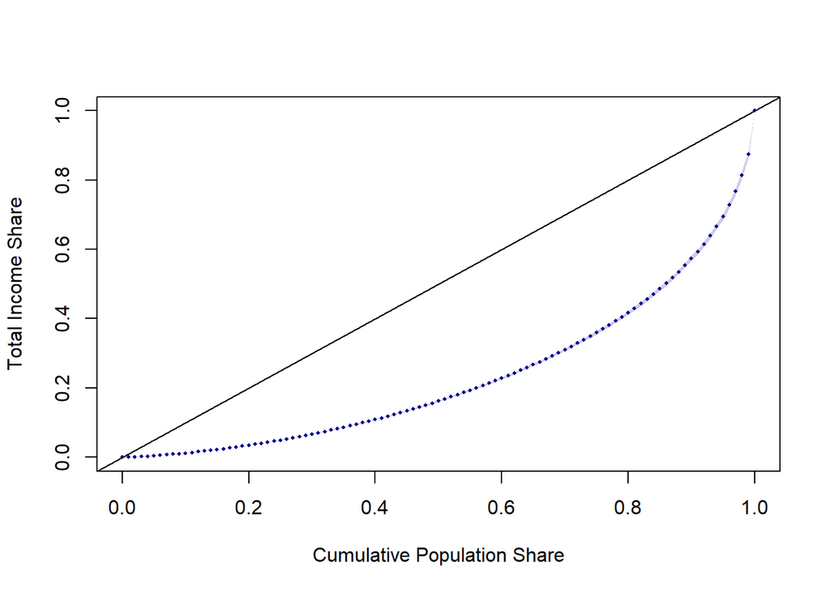

```
...
```

```r
svylorenz(~renda_pc,
          pof_convey,
          quantiles = seq( 0, 1, .01 ),
          curve.col = "darkblue")
```

## Despesa familiar per capita (dfpc)

### despesa média

```r
pof_srvyr %>%
  filter(V0306 != '18' & V0306 != '19') %>%
  summarise(dfpc_media = survey_mean(despesa_pc))
```

```
## # A tibble: 1 × 2
##   dfpc_media dfpc_media_se
##        <dbl>         <dbl>
## 1      1550.          25.8
```

### Percentis

```r
pof_srvyr %>%
  filter(V0306 != "18" & V0306 != "19") %>%
  summarise(dfpc = survey_quantile(despesa_pc,
                            quantiles = c(0.25, 0.50, 0.75,
                                          0.90, 0.95, 0.99)))
```

```
## # A tibble: 1 × 12
##   dfpc_q25 dfpc_q50 dfpc_q75 dfpc_q90 dfpc_q95 dfpc_q99 dfpc_q25_se dfpc_q50_se
##      <dbl>    <dbl>    <dbl>    <dbl>    <dbl>    <dbl>       <dbl>       <dbl>
## 1     508.     921.    1716.    3213.    4868.   10472.        5.07        9.75
## # … with 4 more variables: dfpc_q75_se <dbl>, dfpc_q90_se <dbl>,
## #   dfpc_q95_se <dbl>, dfpc_q99_se <dbl>
```

### Gini e curva de Lorenz

Para o Gini e a curva de Lorez, precisamos transformar nosso objeto `survey.design` com o pacote `convey`:

```r
# pof_convey <- pof_srvyr %>%
#   filter(V0306 != "18" & V0306 != "19") %>%
#   convey_prep()

svygini(~despesa_pc, pof_convey)
```

```
##               gini    SE
## despesa_pc 0.52092 0.005
```

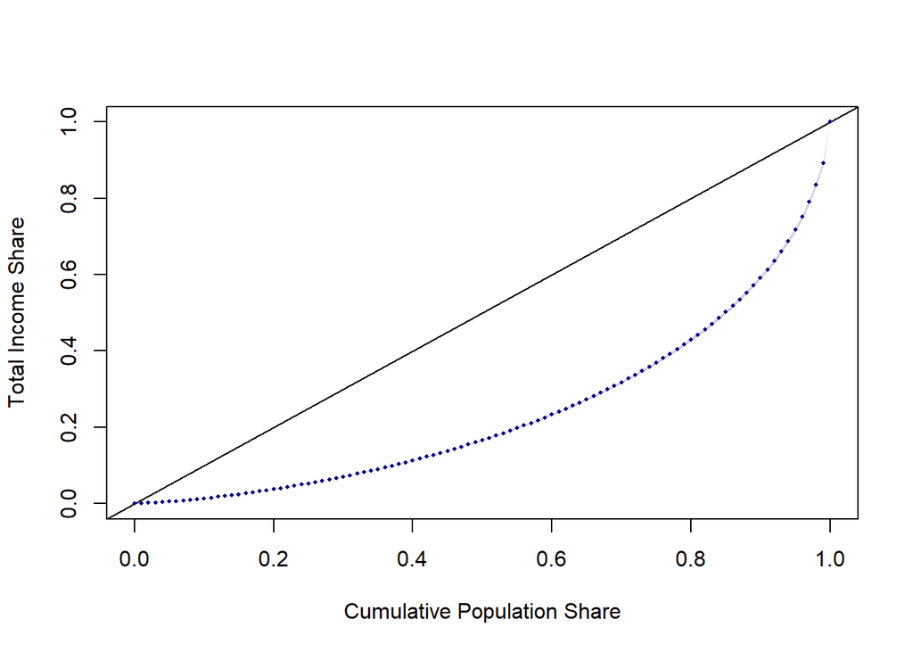

```
...
```

```r
svylorenz(~despesa_pc,
          pof_convey,
          quantiles = seq( 0, 1, .01 ),
          curve.col = "darkblue")
```

OBRIGADO